# Topic Analysis

# Setup

Import packages and helper functions.

```r
library(tidyverse)
library(tidytext)
library(here)
library(purrr)
library(DT)
source(here("Scripts/00_functions.R"))
```

# Import Data

Read topic modeling results and join with paragraph-level data.

```r
documents_with_topics <- read_csv(here("Data/06_documents_with_topics.csv")) |>
  # filter(topic != "-1") |>
  mutate(
    transcript_id = as.character(transcript_id),
    topic_id = as.character(topic + 1)
  ) |>
  select(-topic)

n_documents <- nrow(documents_with_topics)
write_rds(n_documents, here("Outputs/06_n_documents.rds"))

topic_info <- read_csv(here("Data/06_topic_info.csv")) |>
  # filter(topic != "-1") |>
  # rename(topic = Topic, topic_name = Name) |>
  mutate(
    # topic = sprintf("%02d", as.numeric(topic)),
    topic_id = as.character(row_number() - 1),
    OpenAI = str_remove_all(OpenAI, "\\[|\\]|'"),
    OpenAI = ifelse(topic_id == "0", "Outliers", OpenAI),
    KeyBERT = str_remove_all(KeyBERT, "\\[|\\]|'"),
    MMR = str_remove_all(MMR, "\\[|\\]|'")
  ) |>
  select(topic_id, everything(), -c(Topic, Name, Representation))

write_rds(topic_info, here("Data/06_r_topic_info.rds"))

n_topics <- nrow(topic_info) - 1
write_rds(n_topics, here("Outputs/06_n_topics.rds"))

paragraphs_climate <- read_rds(here("Data/05_paragraphs_classified_wide_final.rds")) |>
  filter(final_climate == TRUE) |>
  mutate(
    transcript_id = as.character(transcript_id),
    legislative_period = case_when(
      legislative_period == "50" ~ "50th (2015-2019)",
      legislative_period == "51" ~ "51st (2020-2023)",
      legislative_period == "52" ~ "52nd (2024-2027)",
      .default = as.character(legislative_period)
    )
  )
```

# Visualization Setup

Define party display order and colour palette for all subsequent plots.

```r
parlgroup_order <- c(
  "Sozialdemokratische Fraktion",
  "Grüne Fraktion",
  "Die Mitte-Fraktion / CVP-& BD-Fraktion",
  "Grünliberale Fraktion",
  "FDP-Liberale Fraktion",
  "Fraktion der Schweizerischen Volkspartei"
)

partyabb_order <- c(
  "SP",
  "GPS",
  "Mitte",
  "GLP",
  "FDP",
  "SVP"
)

party_colors <- c(
  "SP" = "#E4032E",
  "GPS" = "#84B547",
  "Mitte" = "#FF8C00",
  "GLP" = "#650959ff",
  "FDP" = "#0571C1",
  "SVP" = "#00843D"
)
```

# Data Preparation

Join topic assignments with paragraph-level metadata and create visualization data.

```r
documents_with_topics_wide <- documents_with_topics |>
  inner_join(topic_info, by = join_by(topic_id))

paragraphs_topics_wide <- documents_with_topics_wide |>
  inner_join(
    paragraphs_climate,
    by = join_by(transcript_id),
    relationship = "one-to-many"
  ) |>
  drop_na(ParlGroupName) |>
  mutate(
    ParlGroupName = factor(ParlGroupName, levels = rev(parlgroup_order)),
    party_abb = factor(ParlGroupName, levels = rev(parlgroup_order), labels = rev(partyabb_order))#,
    # topic = factor(topic, levels = rev(sort(unique(topic))))
  ) |>
  # left_join(mapping_tbl) |>
  # mutate(party_abb = factor(party_abb, levels = rev(party_abb_order))) |>
  group_by(IdSession) |>
  mutate(
    session_median_date = min(meeting_date) + as.numeric(max(meeting_date) - min(meeting_date)) / 2
  ) |>
  ungroup()
```

# Topic Representation

Display topic labels generated by the representation models.

```r
topic_overview <-
  paragraphs_topics_wide |>
  # filter(topic != "-1") |>
  group_by(topic_id, OpenAI) |>
  summarise(
    count = n_distinct(transcript_id),
    .groups = "drop"
  ) |>
  mutate(pct_total = round(count / sum(count) * 100, 1)) |>
  arrange(topic_id)

write_rds(topic_overview, here("Outputs/06_tbl_topic_overview.rds"))
topic_overview |>
  datatable(colnames = c("ID", "LLM Name", "Count", "%"))
```

|  | ID | LLM Name | Count | % |
| --- | --- | --- | --- | --- |
| 1 | 0 | Outliers | 903 | 18.1 |
| 2 | 1 | Swiss Hydropower and Energy Strategy | 1554 | 31.2 |
| 3 | 2 | Climate Policy and Glacier Initiatives | 1212 | 24.3 |
| 4 | 3 | Human Rights and Climate Judgments | 540 | 10.8 |
| 5 | 4 | Biodiversity Crisis in Agriculture | 310 | 6.2 |
| 6 | 5 | Aviation Ticket Tax and Regulation | 209 | 4.2 |
| 7 | 6 | Transport Infrastructure Funding Reform | 203 | 4.1 |
| 8 | 7 | Financial Policy and Budget Challenges | 56 | 1.1 |

Display KeyBERT and MMR representations for each topic.

```r
representation_overview <- topic_info |>
  select(topic_id, OpenAI, KeyBERT, MMR)

representation_overview |>
  datatable()
```

|  | topic_id | OpenAI | KeyBERT | MMR |
| --- | --- | --- | --- | --- |
| 1 | 0 | Outliers | interessenabwägung, kreislaufwirtschaft, ausgleichsmassnahmen, umweltfonds, environnement mondial, einigungskonferenz, sicherheitspolitischen, sicherheitspolitische, angebot, mondial | treibstoffe, fdp liberale, liberale fraktion, wasserstoff, gef, wasserkraft, énergétique, gas, mondial, biogas |
| 2 | 1 | Swiss Hydropower and Energy Strategy | approvisionnement électricité, grosswasserkraft, wasserkraftanlagen, energieversorgung, energiewende, wasserkraft, wasserkraftwerke, energiepolitik, stromverbrauch, production électricité | wasserkraft, winter, energiestrategie 2050, énergies renouvelables, energiegesetzes, kernenergie, stratégie énergétique, kilowattstunde, energiepolitik, approvisionnement électricité |
| 3 | 2 | Climate Policy and Glacier Initiatives | politique climatique, klimapolitik, changements climatiques, klimakrise, klima innovationsgesetz, fonds climat, environnementale, nachhaltigen, emissionshandelssystem, contre projet | klimapolitik, co2 abgabe, contre projet, gletscher initiative, klimakrise, accord paris, politique climatique, volksinitiative, énergies fossiles, planetaren grenzen |
| 4 | 3 | Human Rights and Climate Judgments | kommission rechtsfragen, cour européenne, europäische gerichtshof, antrag kommission, verbandsbeschwerderecht, européenne droits, rechtsfragen, juridiques, rechtsstaat, cette déclaration | egmr, rechtsfragen, droits homme, kommission rechtsfragen, européenne droits, artikel 2a, gerichtshof, cour européenne, verbandsbeschwerderecht, referendum |
| 5 | 4 | Biodiversity Crisis in Agriculture | biodiversitätskrise, biodiversitäts, biodiversität, biodiversitätsgebiete, biodiversität schweiz, biodiversitäts initiative, biodiversitätsförderflächen, biodiversitätsflächen, initiative biodiversité… | biodiversität, contre projet, biodiversitäts, biodiversitäts initiative, biodiversitätsförderflächen, agricoles, biotope, pesticides, animaux, baukultur |
| 6 | 5 | Aviation Ticket Tax and Regulation | luftfahrtgesetzes, flugticketabgaben, loi aviation, billets avion, flugticketabgabe, luftverkehr, luftverkehrs, flugverkehrs, flugverkehr, fluggesellschaften | flugticketabgabe, luftfahrt, flugverkehr, landesflughäfen, aérienne, luftfahrtgesetzes, kerosinsteuer, fluggesellschaften, luftverkehrs, navigation aérienne |
| 7 | 6 | Transport Infrastructure Funding Reform | kommission verkehr, commission transports, routes nationales, projets agglomération, motion commission, strassenfinanzierung, strasseninfrastruktur, initiative dite, spezialfinanzierung, öffentliche v… | routes, véhicules, routes nationales, öffentlichen verkehr, elektrofahrzeuge, transports publics, bus, réseau routes, mobility, strasseninfrastruktur |
| 8 | 7 | Financial Policy and Budget Challenges | teuerungsausgleich, budgethoheit, finanzpolitische, spezialfinanzierung strasse, spezialfinanzierung, frein endettement, sparmassnahmen, netzzuschlagsfonds, stabilisierungsprogramm, crédits engagement | milchkuh initiative, hauptstrassen, sparmassnahmen, milliard francs, initiativkomitee, stabilisierungsprogramm, budgethoheit, netzzuschlagsfonds, intégration, crises |

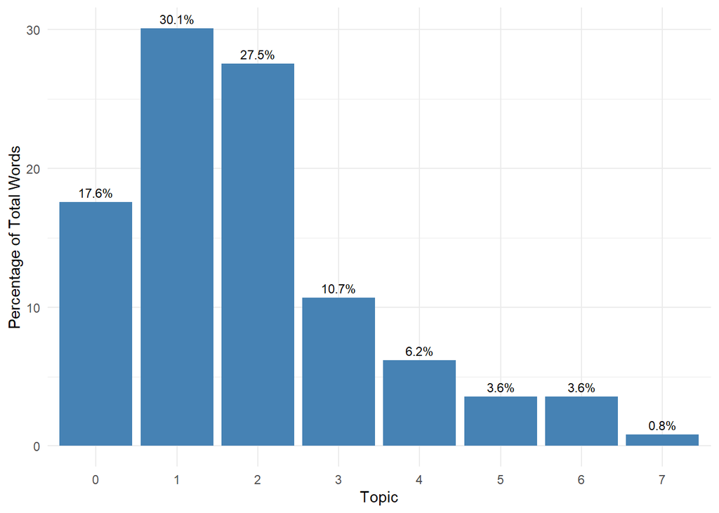

```r
df_topic_distribution <- paragraphs_topics_wide |>
  group_by(topic_id) |>
  summarise(total_words = sum(paragraph_word_count)) |>
  mutate(
    pct_total = total_words / sum(total_words) * 100
  )

p <- ggplot(df_topic_distribution, aes(x = topic_id, y = pct_total)) +
  geom_col(fill = "steelblue") +
  geom_text(
    aes(label = paste0(round(pct_total, 1), "%")),
    vjust = -0.5,
    size = 3
  ) +
  # coord_flip() +
  labs(
    x = "Topic",
    y = "Percentage of Total Words"
  ) +
  theme_minimal()

ggsave(here("Outputs/06_plot_topic_distribution.png"))
write_rds(p, here("Outputs/06_plot_topic_distribution.rds"))
p
```

## Analysis of Topic Representation

Which businesses are most prevalent in each topic?

```r
# topics_bn <-
  paragraphs_topics_wide |>
  # filter(topic != "-1") |>
  group_by(topic_id, Title) |>
  summarise(total_words = sum(paragraph_word_count), .groups = "drop") |>
  arrange(topic_id, desc(total_words)) |>
  group_by(topic_id) |>
  slice_head(n = 5) |>
  ungroup() |>
  datatable()
```

|  | topic_id | Title | total_words |
| --- | --- | --- | --- |
| 1 | 0 | Totalrevision des CO2-Gesetzes nach 2020 | 30079 |
| 2 | 0 | Sichere Stromversorgung mit erneuerbaren Energien. Bundesgesetz | 27609 |
| 3 | 0 | Stromversorgungsgesetz (Stromreserve). Änderung | 17126 |
| 4 | 0 | CO2-Gesetz für die Zeit nach 2024. Revision | 16969 |
| 5 | 0 | Nationalstrassen- und Agglomerationsverkehrs-Fonds (NAF). Schliessung der Finanzierungslücke und Strategisches Entwicklungsprogramm Nationalstrassen | 13661 |
| 6 | 1 | Sichere Stromversorgung mit erneuerbaren Energien. Bundesgesetz | 114805 |
| 7 | 1 | Energiegesetz. Änderung (Beschleunigungserlass) | 57808 |
| 8 | 1 | Energiestrategie 2050, erstes Massnahmenpaket. Für den geordneten Ausstieg aus der Atomenergie (Atomausstiegsinitiative). Volksinitiative | 47551 |
| 9 | 1 | Um- und Ausbau der Stromnetze. Bundesgesetz | 37371 |
| 10 | 1 | Erneuerbare Energien einheitlich fördern. Einmalvergütung auch für Biogas, Kleinwasserkraft, Wind und Geothermie | 33576 |

[output cut: 30 more lines]

Which climate keywords are most prevalent in each topic?

```r
# top_keywords_per_topic <-
  paragraphs_topics_wide |>
  filter(
    keywords_found != ""#,
    # topic != "-1"
  ) |>
  separate_rows(keywords_found, sep = ", ") |>
  group_by(topic_id) |>
  count(keywords_found) |>
  mutate(
    freq = n / sum(n) * 100
  ) |>
  arrange(topic_id, desc(freq)) |>
  slice_head(n = 5) |>
  datatable()
```

|  | topic_id | keywords_found | n | freq |
| --- | --- | --- | --- | --- |
| 1 | 0 | CO2 | 388 | 24.4640605296343 |
| 2 | 0 | climatic | 120 | 7.566204287515762 |
| 3 | 0 | renewable | 87 | 5.485498108448928 |
| 4 | 0 | climate | 81 | 5.10718789407314 |
| 5 | 0 | Climate change | 53 | 3.341740226986128 |
| 6 | 1 | Hydropower | 440 | 12.06801974766868 |
| 7 | 1 | Energy strategy | 389 | 10.66922654964344 |
| 8 | 1 | renewable | 381 | 10.44980800877674 |
| 9 | 1 | CO2 | 255 | 6.993965990126165 |
| 10 | 1 | renewables | 200 | 5.48546352166758 |

[output cut: 30 more lines]

```r
# ggplot(
#   top_keywords_per_topic,
#   aes(
#     x = reorder_within(keywords_found, freq, topic),
#     y = freq,
#     fill = topic)
#   ) +
#   geom_col(show.legend = FALSE) +
#   scale_x_reordered() +
#   coord_flip() +
#   facet_wrap(~ topic, scales = "free_y") +
#   labs(
#     x = NULL,
#     y = "Count"
#   ) +
#   theme_minimal()
```

```r
documents_with_topics |>
  group_by(topic_id) |>
  arrange(desc(topic_probability)) |>
  slice_sample(n = 5) |>
  select(topic_id, transcript_text) |>
  mutate(transcript_text = str_trunc(transcript_text, 200)) |>
  datatable()
```

|  | topic_id | transcript_text |
| --- | --- | --- |
| 1 | 0 | An ihrer Sitzung vom 17. Februar 2020 hat Ihre Kommission die Aussenpolitische Strategie 2020-2023 beraten und zur Kenntnis genommen. Sie beantragt Ihnen, dies ebenfalls zu tun. Eine grosse Diskuss... |
| 2 | 0 | Ich spreche sowohl im Namen der Minderheit, die ich anführe, als auch im Namen der SP-Fraktion zur Vorlage, weshalb ich jetzt etwas länger spreche, dafür nachher nicht mehr. Das sagen aber nicht nu... |
| 3 | 0 | Meine Interessenbindung ist auch bekannt: Ich bin Verwaltungsrat der Axpo. Die Axpo gehört neun Kantonen dieses Landes, und jeder Franken, der erwirtschaftet werden kann, fliesst in Form von System... |
| 4 | 0 | Der Antrag zu Artikel 34a Absatz 1 Buchstabe abis wurde von der UREK-S zusammen mit der Verwaltung entwickelt. Wenn Projekte zur direkten Nutzung von Geothermie scheitern, dann soll auch die indire... |
| 5 | 0 | Effectivement, cela vous a été expliqué précédemment: les représentants de la CEATE-N se sont rendus ce matin à la séance de conciliation en position de faiblesse, puisqu'il n'y avait plus qu'une s... |
| 6 | 1 | Cet article 15 est tout à fait central dans ce projet de loi. En effet, il répond à un problème aigu, dont nous avons certainement tous entendu parler dans nos cantons. Des petits producteurs d'éne... |
| 7 | 1 | In Block 3 geht es bezüglich Differenzbereinigung schwergewichtig um Differenzen in den Bereichen Steuerrecht und Kernenergiegesetz. Es geht mir nun einerseits um die Wirkung im Energiebereich der ... |
| 8 | 1 | Geschätzter Herr Bundesrat Rösti, ich kann Ihren Respekt vor dem Referendum ja gut verstehen. Aber wir wollen ein Gesetz machen, um am Schluss mehr Strom zu haben. Können Sie den Kolleginnen und Ko... |
| 9 | 1 | Für die Versorgungssicherheit der Schweiz im Energiebereich müssen wir uns an einer staatenübergreifenden Zukunftsstrategie beteiligen. Im März 2022 haben Norwegen und Deutschland ein Projekt ins L... |
| 10 | 1 | Die beste Energie ist die, die wir gar nicht verbrauchen. Im Zusammenhang mit der Debatte über Energieeffizienz hat sich diese Erkenntnis etabliert. Bei der Verwendung von kohlenstoffhaltigen Produ... |

[output cut: 30 more lines]

## Party Distribution per Topic

Party composition across all topics (stacked bar charts) based on word counts.

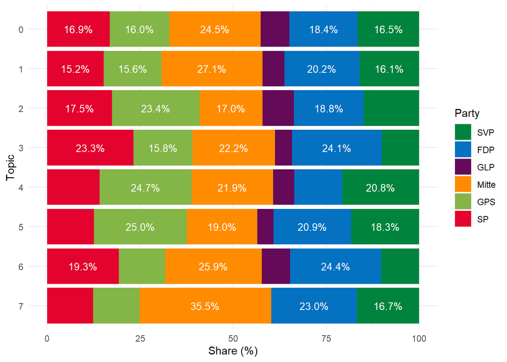

```r
df_plot <- paragraphs_topics_wide |>
  mutate(topic_id = factor(topic_id, levels = rev(sort(unique(topic_id))))) |>
  # filter(topic_id %in% c("1", "2", "4", "5", "6")) |>
  group_by(topic_id, party_abb) |>
  summarise(
    group_words = sum(paragraph_word_count),
    .groups = 'drop_last'
  ) |>
  mutate(
    pct_of_topic = group_words / sum(group_words) * 100
  ) |>
  drop_na()

p <- ggplot(
  df_plot,
  aes(x = pct_of_topic, y = topic_id, fill = party_abb)
) +
  geom_col(position = "stack") +
  geom_text(
    aes(
      label = ifelse(pct_of_topic > 15, sprintf("%.1f%%", pct_of_topic), "")
    ),
    position = position_stack(vjust = 0.5),
    color = "white",
    size = 3.5) +
  scale_fill_manual(values = party_colors) +
  labs(
    x = "Share (%)",
    y = "Topic",
    fill = "Party"
  ) +
  theme_minimal() +
  theme(
    legend.position = "right"
  )

ggsave(here("Outputs/06_plot_topic_party_distribution.png"))
write_rds(p, here("Outputs/06_plot_topic_party_distribution.rds"))
p
```

# Compare Topic Representation by Party

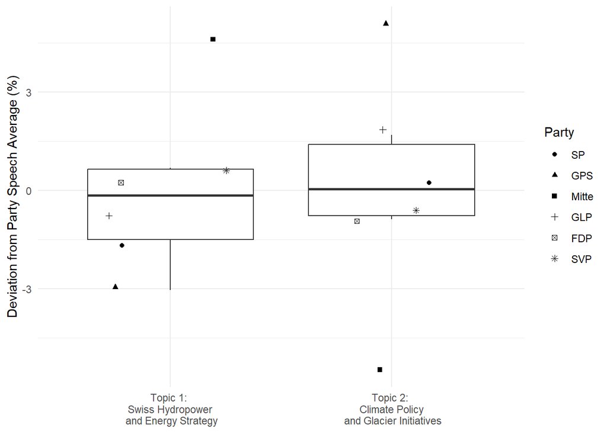

```r
counts <- paragraphs_topics_wide |>
  filter(topic_id %in% c("1", "2")) |>
  # filter(topic_id %in% c("3", "4", "5", "6", "7")) |>
  group_by(party_abb, topic_id) |>
  summarise(
    wordcount_party_topic = sum(paragraph_word_count),
    .groups = "drop"
  ) |>
  left_join(
    paragraphs_topics_wide |>
      group_by(party_abb) |>
      summarise(wordcount_party = sum(paragraph_word_count), .groups = "drop"),
    by = "party_abb"
  )

shares <- counts |>
  group_by(topic_id) |>
  mutate(
    party_share_in_topic = wordcount_party_topic / sum(wordcount_party_topic) * 100
  ) |>
  ungroup() |>
  select(party_abb, topic_id, party_share_in_topic) |>
  pivot_wider(
    names_from = topic_id,
    names_prefix = "party_share_in_topic",
    values_from = party_share_in_topic
  ) |>
  left_join(
    paragraphs_topics_wide |>
      group_by(party_abb) |>
      summarise(
        wordcount_party = sum(paragraph_word_count),
        .groups = "drop"
      ) |>
      mutate(party_share_in_parl = wordcount_party / sum(wordcount_party) * 100) |>
      select(party_abb, party_share_in_parl),
    by = "party_abb"
  ) |>
  select(party_abb, party_share_in_parl, starts_with("party_share_in_topic"))

shares_long <- shares |>
  pivot_longer(
    cols = starts_with("party_share_in_topic"),
    names_to = "topic_id",
    values_to = "party_share_in_topic"
  ) |>
  mutate(
    topic_id = str_remove(topic_id, "party_share_in_topic"),
    topic_id = factor(as.numeric(topic_id), levels = sort(unique(as.numeric(topic_id)))),
    topic_diff = party_share_in_topic - party_share_in_parl,
    topic_ratio = (party_share_in_topic / party_share_in_parl -1) * 100,
    party_abb = fct_rev(factor(party_abb))
  )

labels_map <- setNames(as.character(levels(shares_long$topic_id)), levels(shares_long$topic_id))
labels_map["1"] <- "Topic 1: \n Swiss Hydropower \n and Energy Strategy"
labels_map["2"] <- "Topic 2: \n Climate Policy \n and Glacier Initiatives"

p <-  ggplot(
  shares_long,
  aes(x = topic_id, y = topic_diff)
) +
  geom_boxplot(outliers = FALSE) +
  geom_jitter(width = 0.3, height = 0.3, aes(shape = party_abb)) +
  scale_x_discrete(labels = labels_map) +
  labs(
    x = NULL,
    y = "Deviation from Party Speech Average (%)",
    shape = "Party"
  ) +
  theme_minimal()
  # theme(
  #   axis.text.x = element_text(angle = 45, hjust = 1)
  # )
ggsave(here("Outputs/06_plot_topic_party_comparison.png"))
write_rds(p, here("Outputs/06_plot_topic_party_comparison.rds"))
# ggsave(here("Outputs/06_plot_topics_3_to_7_party_emphasis.png"))
# write_rds(p, here("Outputs/06_plot_topics_3_to_7_party_emphasis.rds"))
p
```

# Statistical Analysis

## Chi-Squared Test

Test statistical association between party and topic.

```r
df <- paragraphs_topics_wide |>
  distinct(transcript_id, topic_id, party_abb) |>
  mutate(
    topic_1 = factor(ifelse(topic_id == "1", 1, 0)),
    topic_2 = factor(ifelse(topic_id == "2", 1, 0)),
    GPS = factor(ifelse(party_abb == "GPS", 1, 0)),
    Mitte = factor(ifelse(party_abb == "Mitte", 1, 0)),
    FDP = factor(ifelse(party_abb == "FDP", 1, 0)),
    SVP = factor(ifelse(party_abb == "SVP", 1, 0)),
    GLP = factor(ifelse(party_abb == "GLP", 1, 0)),
    SP = factor(ifelse(party_abb == "SP", 1, 0))
  )

perform_chisq_test <- function(party) {
  chisq_test_1 <- chisq.test(table(df[[party]], df$topic_1))
  chisq_test_2 <- chisq.test(table(df[[party]], df$topic_2))
  results <- tibble(
    party = party,
    topic = c("Topic 1", "Topic 2"),
    statistic = c(chisq_test_1$statistic, chisq_test_2$statistic),
    df = c(chisq_test_1$parameter, chisq_test_2$parameter),
    p_value = c(chisq_test_1$p.value, chisq_test_2$p.value),
  )
  return(results)
}

n_parties <- n_distinct(df$party_abb)
sig_adj <- 0.05 / (n_parties * 2) # Bonferroni correction for multiple tests

chisq_test_results <- map_df(
  distinct(df, party_abb) |> pull(party_abb),
  perform_chisq_test
  )  |>
  arrange(topic, party) |>
  mutate(
    statistic = round(statistic, 3),
    p_value = paste0(
    round(p_value, 3),
    case_when(
      p_value < sig_adj ~ "***",
      p_value < 0.01 ~ "**",
      p_value < 0.05 ~ "*",
      TRUE ~ ""
    )
  )
)

write_rds(chisq_test_results, here("Outputs/06_chi_squared_results.rds"))

library(knitr)
library(kableExtra)
chisq_test_results |>
  kable(
    col.names = c("Party", "Topic", "χ²", "df", "p-value")
  ) |>
  footnote(
    general = "* p < 0.05, ** p < 0.01, *** p < 0.005 (Bonferroni-adjusted)",
    general_title = "",
    footnote_as_chunk = TRUE
  )
```

| Party | Topic | χ² | df | p-value |
| --- | --- | --- | --- | --- |
| SVP | Topic 1 | 0.232 | 1 | 0.63 |
| FDP | Topic 1 | 2.112 | 1 | 0.146 |
| GLP | Topic 1 | 4.925 | 1 | 0.026* |
| Mitte | Topic 1 | 55.904 | 1 | 0*** |
| GPS | Topic 1 | 8.005 | 1 | 0.005** |
| SP | Topic 1 | 4.368 | 1 | 0.037* |
| SVP | Topic 2 | 0.010 | 1 | 0.921 |
| FDP | Topic 2 | 0.302 | 1 | 0.583 |
| GLP | Topic 2 | 5.366 | 1 | 0.021* |
| Mitte | Topic 2 | 52.240 | 1 | 0*** |
| GPS | Topic 2 | 41.615 | 1 | 0*** |
| SP | Topic 2 | 1.132 | 1 | 0.287 |

## Regression Analysis

```r
# create dummy variables for topics 1 to 7
regression_data <- paragraphs_topics_wide |>
  distinct(transcript_id, topic_id, party_abb) |>
  mutate(
    topic_1 = factor(ifelse(topic_id == 1, 1, 0)),
    topic_2 = factor(ifelse(topic_id == 2, 1, 0)),
    topic_3 = factor(ifelse(topic_id == 3, 1, 0)),
    topic_4 = factor(ifelse(topic_id == 4, 1, 0)),
    topic_5 = factor(ifelse(topic_id == 5, 1, 0)),
    topic_6 = factor(ifelse(topic_id == 6, 1, 0)),
    topic_7 = factor(ifelse(topic_id == 7, 1, 0)),
    party_abb = relevel(factor(party_abb), ref = "SP") # change according to hypothesis
  )
```

What influence does party affiliation have on topic assignment?

```r
# for loop over topics
models <- list()
for (i in 1:2) {
  formula <- as.formula(paste0("topic_", i, " ~ party_abb"))
  model <- glm(formula, data = regression_data, family = binomial())
  models[[paste0("model_", i)]] <- model
}

# save models
write_rds(models, here("Outputs/06_regression_models.rds"))

# print summary of each model
for (i in 1:2) {
  cat(paste0("Model for Topic ", i, ":\n"))
  print(summary(models[[paste0("model_", i)]]))
  cat("\n\n")
}
```

```
Model for Topic 1:

Call:
glm(formula = formula, family = binomial(), data = regression_data)

Coefficients:
               Estimate Std. Error z value Pr(>|z|)
(Intercept)    -0.94620    0.07872 -12.019  < 2e-16 ***
party_abbSVP    0.12120    0.10499   1.154    0.248
party_abbFDP    0.05673    0.10670   0.532    0.595
party_abbGLP   -0.12772    0.15020  -0.850    0.395
party_abbMitte  0.54431    0.09885   5.506 3.66e-08 ***
party_abbGPS   -0.05805    0.11257  -0.516    0.606
---
Signif. codes:  0 '***' 0.001 '**' 0.01 '*' 0.05 '.' 0.1 ' ' 1

(Dispersion parameter for binomial family taken to be 1)

    Null deviance: 6187.7  on 4986  degrees of freedom
Residual deviance: 6128.2  on 4981  degrees of freedom
AIC: 6140.2

Number of Fisher Scoring iterations: 4



Model for Topic 2:

Call:
glm(formula = formula, family = binomial(), data = regression_data)

Coefficients:
               Estimate Std. Error z value Pr(>|z|)
(Intercept)    -1.05416    0.08071 -13.061  < 2e-16 ***
party_abbSVP   -0.09136    0.11000  -0.831 0.406235
party_abbFDP   -0.12309    0.11163  -1.103 0.270139
party_abbGLP    0.19797    0.14614   1.355 0.175507
party_abbMitte -0.58125    0.11315  -5.137 2.79e-07 ***
party_abbGPS    0.36482    0.11057   3.300 0.000968 ***
---
Signif. codes:  0 '***' 0.001 '**' 0.01 '*' 0.05 '.' 0.1 ' ' 1

(Dispersion parameter for binomial family taken to be 1)

    Null deviance: 5531.1  on 4986  degrees of freedom
Residual deviance: 5447.4  on 4981  degrees of freedom
AIC: 5459.4

Number of Fisher Scoring iterations: 4
```

```r
# use stargazer to create a summary table of all models
library(stargazer)
stargazer(models, type = "text", title = "Logistic Regression Results", align = TRUE)
```

```
Logistic Regression Results
==============================================
                      Dependent variable:
                  ----------------------------
                     topic_1        topic_2
                       (1)            (2)
----------------------------------------------
party_abbSVP          0.121         -0.091
                     (0.105)        (0.110)

party_abbFDP          0.057         -0.123
                     (0.107)        (0.112)

party_abbGLP          -0.128         0.198
                     (0.150)        (0.146)

party_abbMitte       0.544***      -0.581***
                     (0.099)        (0.113)

party_abbGPS          -0.058       0.365***
                     (0.113)        (0.111)

Constant            -0.946***      -1.054***
                     (0.079)        (0.081)

----------------------------------------------
Observations          4,987          4,987
Log Likelihood      -3,064.089    -2,723.714
Akaike Inf. Crit.   6,140.177      5,459.427
==============================================
Note:              *p<0.1; **p<0.05; ***p<0.01
```

# Compare Legislative Periods

Create visualizatin like tihs:

boxplot combined with scatter points, where each point represents a party’s share in a topic for a given legislative period.

on y axis: the diff_from_parl of all parties for a given topic on x axis: legislative period

variables in data: topic_id, party_abb, legislative_period variable to calculate: diff_from_parl

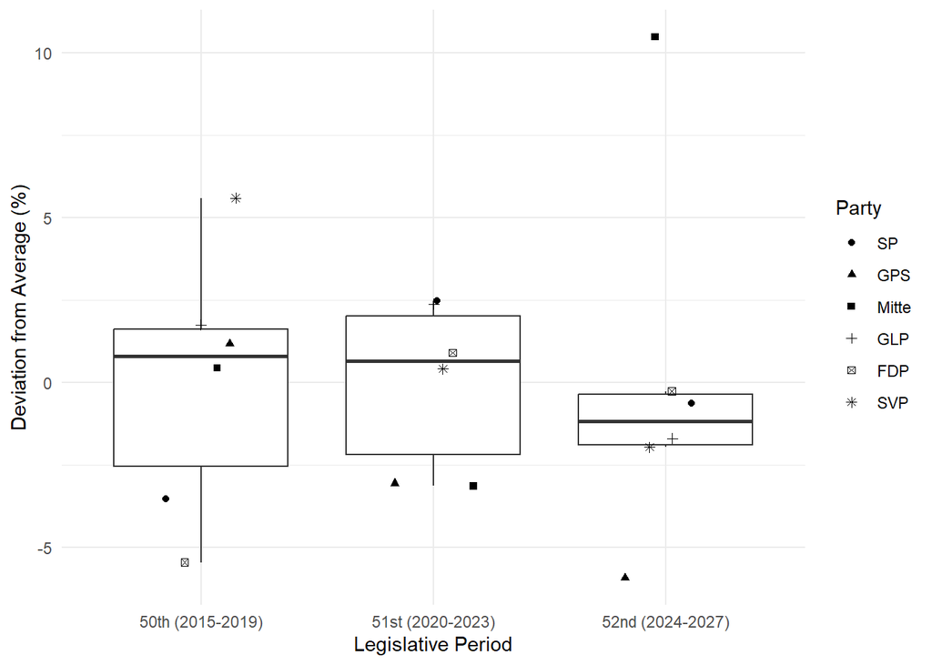

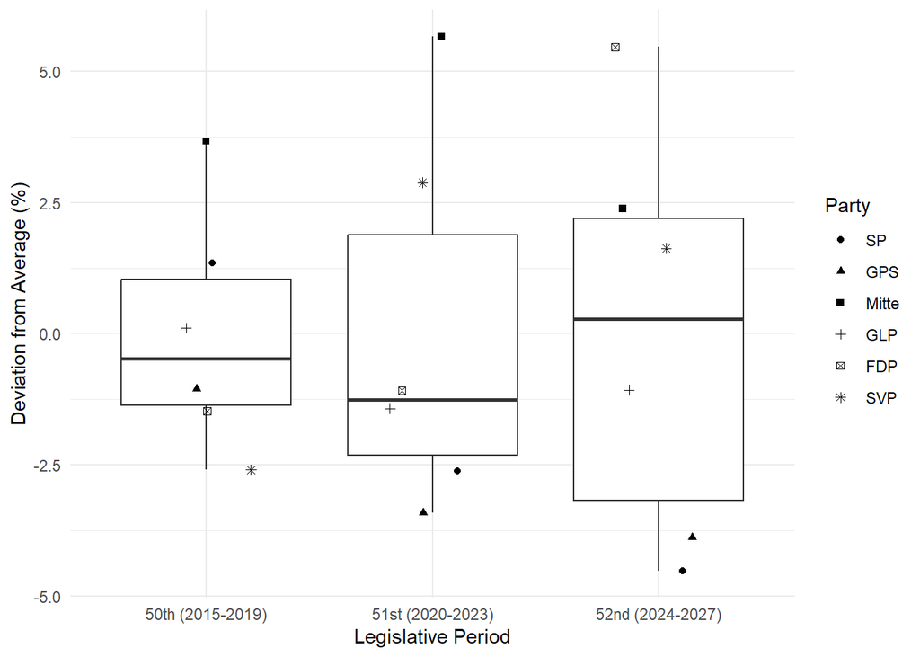

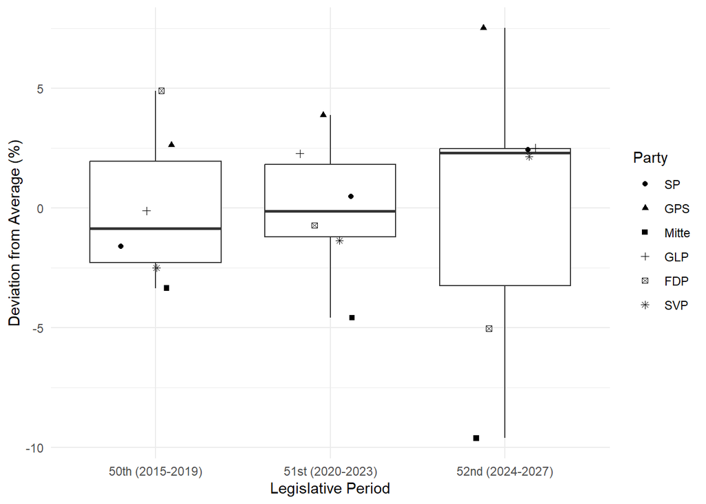

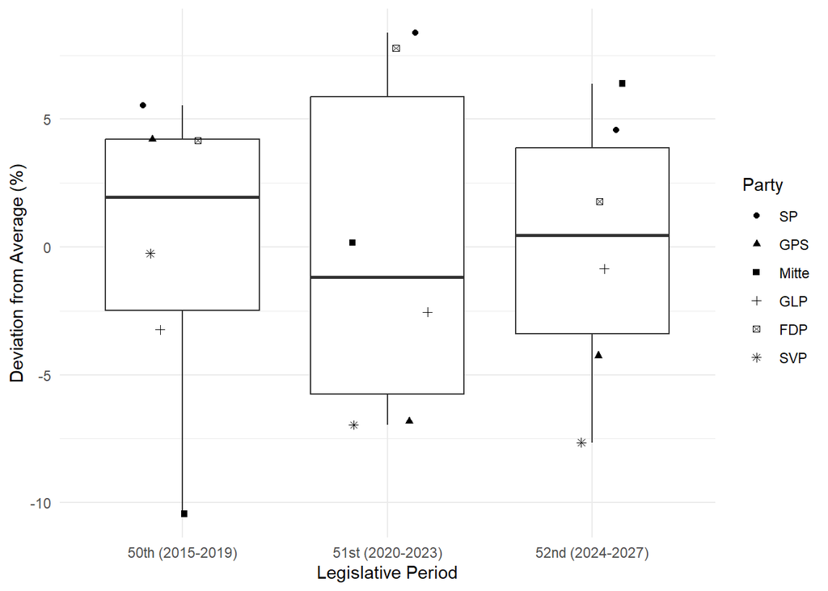

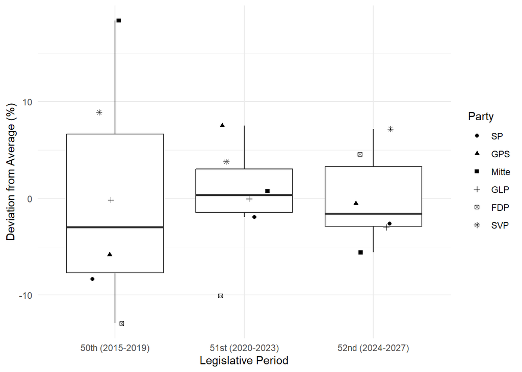

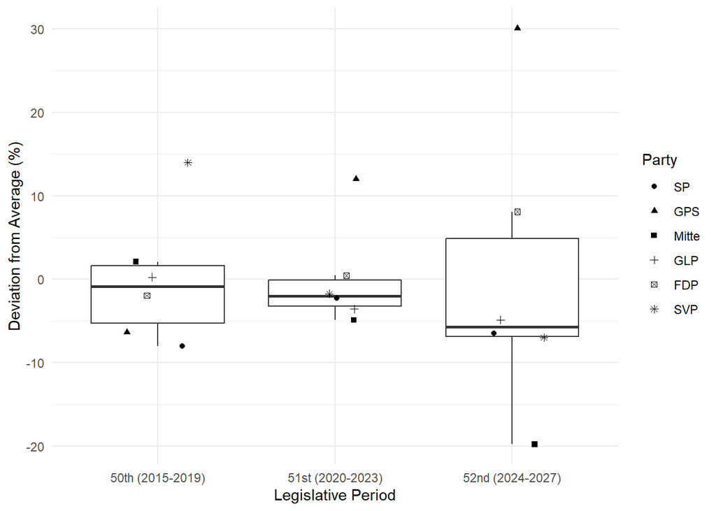

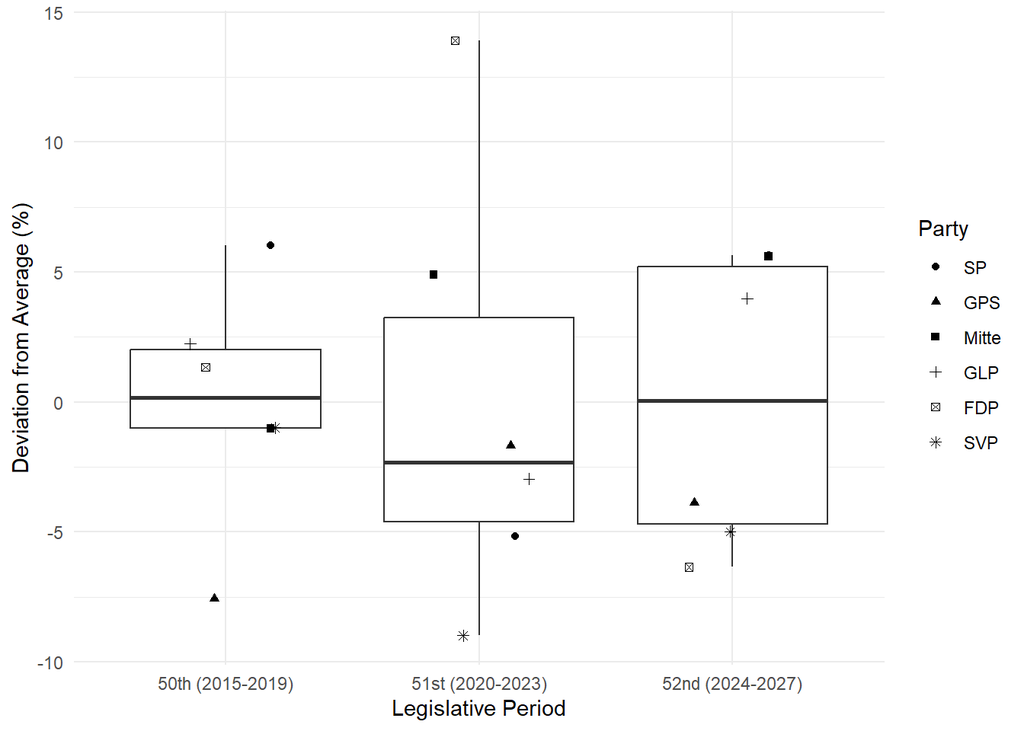

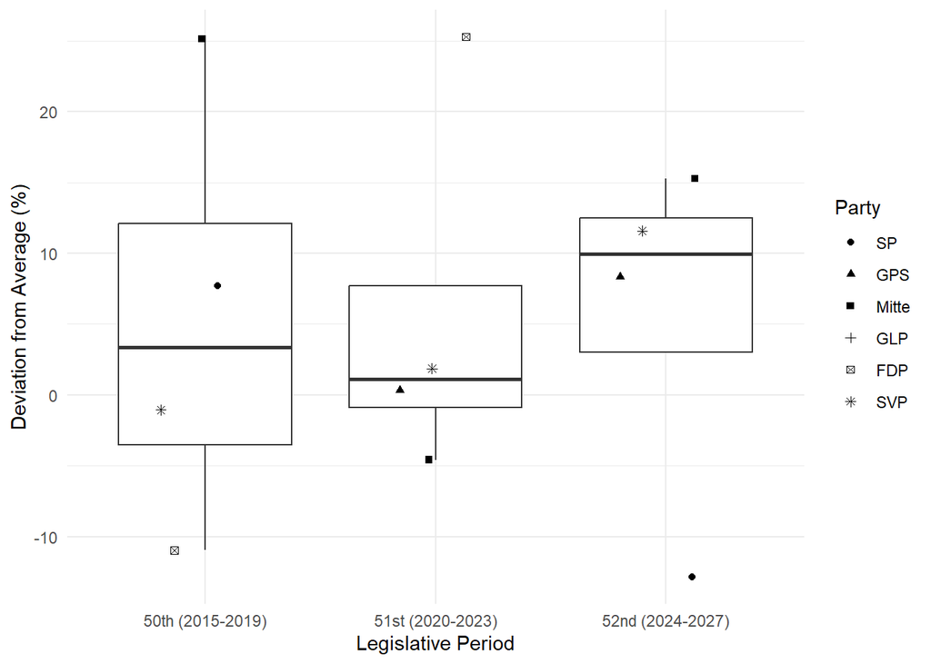

```r
counts <- paragraphs_topics_wide |>
  group_by(party_abb, topic_id, legislative_period) |>
  summarise(
    wordcount_party_topic = sum(paragraph_word_count),
    .groups = "drop"
  ) |>
  left_join(
    paragraphs_topics_wide |>
      group_by(party_abb) |>
      summarise(wordcount_party = sum(paragraph_word_count), .groups = "drop"),
    by = "party_abb"
  )

shares <- counts |>
  group_by(topic_id, legislative_period) |>
  mutate(
    party_share_in_topic = wordcount_party_topic / sum(wordcount_party_topic) * 100
  ) |>
  ungroup() |>
  select(party_abb, topic_id, legislative_period, party_share_in_topic) |>
  pivot_wider(
    names_from = topic_id,
    names_prefix = "party_share_in_topic",
    values_from = party_share_in_topic
  ) |>
  left_join(
    paragraphs_topics_wide |>
      group_by(party_abb, legislative_period) |>
      summarise(wordcount_party = sum(paragraph_word_count), .groups = "drop") |>
      group_by(legislative_period) |>
      mutate(party_share_in_parl = wordcount_party / sum(wordcount_party) * 100) |>
      select(party_abb, legislative_period, party_share_in_parl),
    by = c("party_abb", "legislative_period")
  ) |>
  select(party_abb, legislative_period, party_share_in_parl, starts_with("party_share_in_topic"))

shares_long <- shares |>
  pivot_longer(
    cols = starts_with("party_share_in_topic"),
    names_to = "topic_id",
    values_to = "party_share_in_topic"
  ) |>
  mutate(
    topic_id = str_remove(topic_id, "party_share_in_topic"),
    topic_id = factor(as.numeric(topic_id), levels = rev(sort(unique(as.numeric(topic_id))))),
    topic_diff = party_share_in_topic - party_share_in_parl,
    topic_ratio = (party_share_in_topic / party_share_in_parl -1) * 100,
    party_abb = fct_rev(factor(party_abb))
  )

plots <- map(unique(shares_long$topic_id), function(topic) {
  df_plot <- shares_long |>
    filter(topic_id == topic)

  ggplot(df_plot, aes(x = legislative_period, y = topic_diff)) +
    geom_boxplot(outliers = FALSE) +
    geom_jitter(width = 0.2, height = 0, aes(shape = party_abb)) +
    labs(
      x = "Legislative Period",
      y = "Deviation from Average (%)",
      shape = "Party"
    ) +
    theme_minimal()
})

walk2(plots, unique(shares_long$topic_id), function(plot, topic) {
  dir.create(here("Outputs/06_topics_timeseries"), showWarnings = FALSE)
  ggsave(
    filename = here(paste0("Outputs/06_topics_timeseries/06_plot_period_comparison_topic_", topic, ".png")),
    plot = plot
  )
  write_rds(
    plot,
    here(paste0("Outputs/06_topics_timeseries/06_plot_period_comparison_topic_", topic, ".rds"))
  )
})
plots
```